# Lab 3: CNNs and Deep Learning

**(version 1.0)**

### TBMI26/732A55 Neural Networks and Learning Systems 2020

### Michael Felsberg

#### *Hint: Use the provided test cases to check if your solutions are valid.*

## 2D Convolution

It is widely used with 2D signals such as images. For the further steps, we often need to visualize an image and we define a shortcut for that:

```python
from matplotlib import pyplot as plt

def visualize(img, title=''):
    plt.imshow(img,'gray')
    plt.colorbar()
    plt.title(title)
    plt.show()
    print('Image size:', img.shape)
```

**Task 1:** Convolution can be performed in 2D using the function `scipy.signal.convolove2d()`. Use this function to generate a 2D kernel of size $33\times33$ by five times cascading 2D convolutions of $H$ with itself, starting with $H = \begin{array}{|c|c|} \hline 1 & 1 \\ \hline 1 & 1 \\ \hline \end{array}/4$.  
*Visualize* the kernel using `visualize` function defined above.

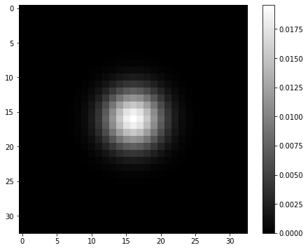

```
Image size: (33, 33)
```

```python
from scipy import signal

H = [1/4, 1/4], [1/4, 1/4]
for i in range(0,5):
    H = signal.convolve2d(H,H)


visualize(H)
```

```python
### TEST CELL. PLEASE DON'T CHANGE ###
assert(H.sum().round()==1)
```

What differences do you observe regarding the size of the output?

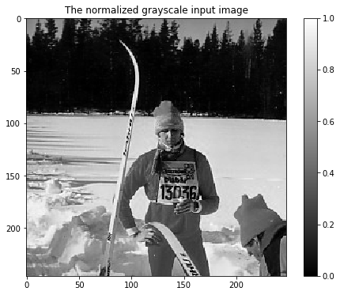

```
Image size: (246, 248)
```

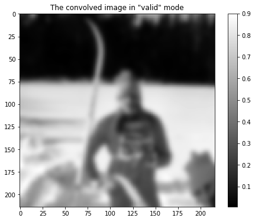

```
Image size: (214, 216)
```

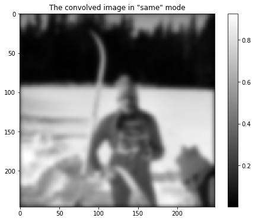

```
Image size: (246, 248)
```

```python
import matplotlib.pyplot as plt
import matplotlib.image as mpimg
import numpy as np

img=mpimg.imread('MR15^044.JPG')
img_gray = img.sum(axis=2)/np.max(img.sum(axis=2))
omg_sc_valid = signal.convolve2d(img_gray, H, 'valid')
omg_sc_same = signal.convolve2d(img_gray, H, 'same')

visualize(img_gray, 'The normalized grayscale input image')
visualize(omg_sc_valid, 'The convolved image in "valid" mode')
visualize(omg_sc_same, 'The convolved image in "same" mode')
```

```python
### TEST CELL. PLEASE DON'T CHANGE ###
assert(img_gray.max() == 1.0)
assert(omg_sc_valid.shape == (214, 216))
assert(omg_sc_same.shape == (246, 248))
```

## Strided convolution

In strided convolution, samples are removed based on the stride. According to the Nyquist theorem, this can generate aliasing artifacts.

*Hint*: Use Python extended slicing, read this guid on [extended slices](https://docs.python.org/2.3/whatsnew/section-slices.html)

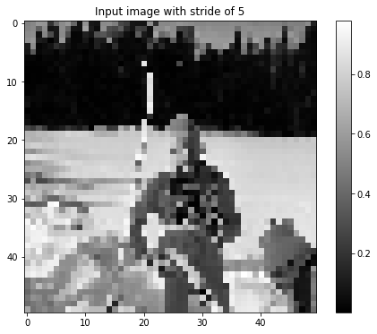

```
Image size: (50, 50)
```

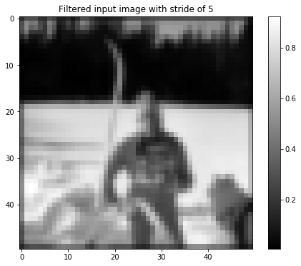

```
Image size: (50, 50)
```

```python
img_gray_ds = img_gray[::5,::5]
omg_sc_same_ds = omg_sc_same[::5,::5]


visualize(img_gray_ds, 'Input image with stride of 5')
visualize(omg_sc_same_ds, 'Filtered input image with stride of 5')
```

What do you observe, in particular at the ski?

## Convolution in PyTorch

PyTorch is an open source machine learning library based on the Torch library, used for applications such as computer vision and natural language processing. It is primarily developed by Facebook's AI Research lab.

We will start by utilizing PyTorch to perform convolution operations in 2D.

**Task 4:** Apply the cascaded $33\times33$ filter from task 1 to the image using a `torch.nn.Conv2d` layer.

Compare the results from *Scipy* in task 2 and *PyTorch* in this task by subtracting the output images.

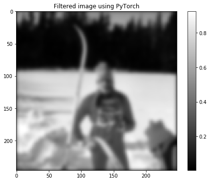

```
Image size: (246, 248)
```

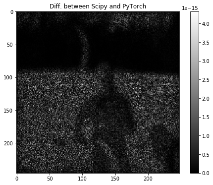

```
Image size: (246, 248)
```

```python
import torch
import torch.nn.functional as F

img_gray1 = torch.tensor(img_gray)
img_gray1 = img_gray1.unsqueeze_(0)
img_gray1 = img_gray1.unsqueeze_(0)

H1 = torch.tensor(H)
H1 = H1.unsqueeze_(0)
H1 = H1.unsqueeze_(0)


out_2d_np = F.conv2d(img_gray1, H1, padding = 16 )

out_2d_np = out_2d_np.numpy()

out_2d_np = out_2d_np[0,0,:,:]





# Hint: Convert the output tensor to numpy array
visualize(out_2d_np, 'Filtered image using PyTorch')
diff = np.abs(out_2d_np-omg_sc_same)
visualize(diff, 'Diff. between Scipy and PyTorch')
```

```python
### TEST CELL. PLEASE DON'T CHANGE ###
assert(diff.mean()<1e-7)
```

**Task 5:** Repeat the previous task with stride 5. Compare with `omg_sc_same_ds` from task 3.

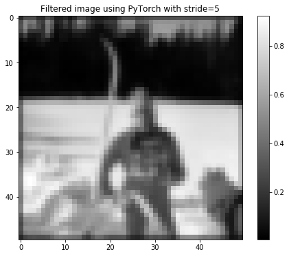

```
Image size: (50, 50)
```

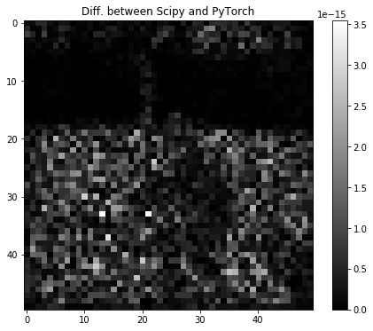

```
Image size: (50, 50)
```

```python
import torch
img_gray1 = torch.tensor(img_gray)
img_gray1 = img_gray1.unsqueeze_(0)
img_gray1 = img_gray1.unsqueeze_(0)

H1 = torch.tensor(H)
H1 = H1.unsqueeze_(0)
H1 = H1.unsqueeze_(0)


out_2d_s5_np = F.conv2d(img_gray1, H1, stride = 5, padding = 16)

out_2d_s5_np = out_2d_s5_np.numpy()



out_2d_s5_np = out_2d_s5_np[0,0,:,:]


# Hint: Convert the output tensor to numpy array
visualize(out_2d_s5_np, 'Filtered image using PyTorch with stride=5')
diff_s5 = np.abs(out_2d_s5_np-omg_sc_same_ds)
visualize(diff_s5, 'Diff. between Scipy and PyTorch')
```

```python
### TEST CELL. PLEASE DON'T CHANGE ###
assert(diff_s5.mean()<1e-6)
```

**Task 6:** Repeat task 5 with stride of 5 and a $1\times1$ filter. Compare with `img_gray_ds` from task 3.

```
1.0
```

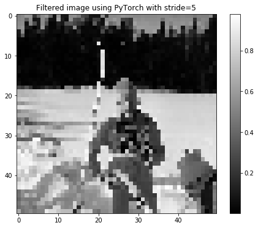

```
Image size: (50, 50)
```

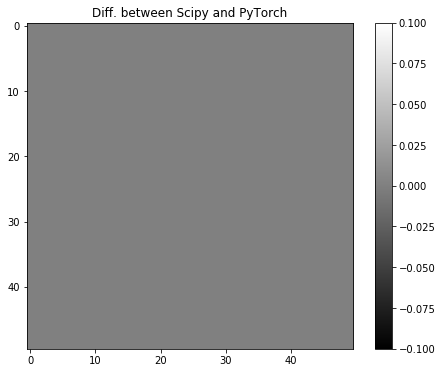

```
Image size: (50, 50)
```

```python
img_gray1 = torch.tensor(img_gray)
img_gray1 = img_gray1.unsqueeze_(0)
img_gray1 = img_gray1.unsqueeze_(0)

H1 = torch.ones([1,1,1,1])
H1[0,0,0,0] = 1
H1 = H1.double()
print(sum(sum(H)))



out_2d_s5_1_np = F.conv2d(img_gray1, H1, stride = 5, padding = 0)

out_2d_s5_1_np = out_2d_s5_1_np.numpy()

out_2d_s5_1_np = out_2d_s5_1_np[0,0,:,:]

# Hint: Convert the output tensor to numpy array
visualize(out_2d_s5_1_np, 'Filtered image using PyTorch with stride=5')
diff_s5_1 = np.abs(out_2d_s5_1_np-img_gray_ds)

visualize(diff_s5_1, 'Diff. between Scipy and PyTorch')
```

```python
### TEST CELL. PLEASE DON'T CHANGE ###
assert(diff_s5_1.mean()<1e-7)
```

## Training a PyTorch Convolution layer

Now, we want the network to learn the convolution filter given the input and the filtered output.

**Task 7:** Considering the input image tensor `inp_2d` from task 4 as a *batch* and the filtered output `out_2d_t` as a label, use `torch.optim.SGD` to learn the the filter $H$.

**Hints**:

- Use the L1 loss from `torch.nn.functional.l1_loss`.
- Use a small learning rate.
- Detach `out_2d_t` from the model graph in task 4 to avoid errors.
- Iterate for 500 iterations.
- Clip the weights after each iteration to $[0, \infty[$ for stable convergence.
- Print the loss every 100 steps.

```python
import torch.optim as optim
import torch.nn as nn
import torch.nn.functional as F
import torch.nn.functional as F

net = nn.Sequential(nn.Conv2d(1,1,33,padding = 16))



criterion = nn.functional.l1_loss
optimizer = optim.SGD(net.parameters(), lr=0.0001, momentum=0.9)

for i in range (1,500):
        # zero the parameter gradients
        optimizer.zero_grad()

        # forward + backward + optimize
        outputs = net(img_gray1.float())
        outputs = outputs[0,0,:,:]

        loss = criterion(outputs, torch.tensor(out_2d_np))
        loss.backward()

        optimizer.step()

        for p in net.parameters():
            p.data.clamp_(0)

        if (i%100) == 0:
            print(loss.item())


# Visualize the trained filter


visualize(list(net.parameters())[0][0][0].detach().cpu().numpy())
print(sum(sum(list(net.parameters())[0][0][0].detach().cpu().numpy()-H))/sum(sum(H)))
```

[output not shown]

[output not shown]

**Task 8**: To make the transitiong to the next task easier, redo task 7 by defining a custom PyTorch module which includes only 1 convolution layer.  
You can follow this [tutorial](https://pytorch.org/tutorials/beginner/blitz/neural_networks_tutorial.html#define-the-network).  
A custom module class inherits `torch.nn.Module` class and needs to have two mandatory functions:

- `__init__(self):` where you define layers included in your module.
- `forward(self, x):` where you define the inference steps of your network.

The built-in auto-differentiation module in PyTorch will keep track of the operations that you perform in the inference steps and calculates their derivatives when you back-propagate the loss function during training.

```python
class Net(nn.Module):
    def __init__(self):
        super(Net, self).__init__()
        self.conv1 = nn.Conv2d(1,1,33,padding = 16)

    def forward(self, x):
        x = (self.conv1(x))
        return x

net = Net()


criterion = nn.functional.l1_loss
optimizer = optim.SGD(net.parameters(), lr=0.001, momentum=0.9)




for i in range (500):
        # zero the parameter gradients
        optimizer.zero_grad()

        # forward + backward + optimize
        outputs = net(img_gray1.float())
        outputs = outputs[0,0,:,:]
        loss = criterion(outputs, torch.tensor(out_2d_np))

        loss.backward()
        optimizer.step()

        for p in net.parameters():
            p.data.clamp_(0)

        if (i%100) == 0:
            print(loss.item())

# Visualize the trained filter
visualize(net.conv1.weight[0,0,:,:].detach().cpu().numpy())
```

[output not shown]

## Training a whole network

So far, we have experimented with training a single convolution layer. Now we try to train a whole network to perform the task of image classification on CIFAR-10 dataset.  
But first, make sure that CUDA is available by running the following command:

```python
import torch
print("CUDA Available: ",torch.cuda.is_available())
```

[output not shown]

**Task 9:** We will train on CIFAR10, which is readily available at `torchvision.datasets.CIFAR10`.

Create a dataloader for the *training* and the *test* sets of CIFAR10 using `torch.utils.data.DataLoader` , then show some examples from the training set using `torchvision.utils.make_grid` and print out their labels.

*Hints* :

- The `imshow` function for visualizing the images is provided below.
- Use `torchvision.transforms` to perform whitening on images (normalization using the mean and the standard deviation).
- Use a batch size of 64.

```
Files already downloaded and verified
Files already downloaded and verified
Files already downloaded and verified
```

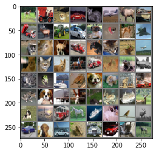

```
horse truck   dog   car   cat plane  deer  ship truck  deer truck   car   dog   dog  deer plane  ship  deer   dog truck   dog   cat  deer plane   cat   cat   dog horse truck  deer  frog truck  frog  frog  ship  bird   dog   dog   cat truck   cat   dog truck   dog  bird  frog  ship  deer   dog plane …
```

```python
import torch
import matplotlib.pyplot as plt
import numpy as np
import torchvision
import torchvision.transforms as transforms


def imshow(img, mean, std):
    npimg = img.numpy()

    for i in range(3):
        npimg[i] = npimg[i] * std[i] + mean[i]

    plt.imshow(np.transpose(npimg, (1, 2, 0)))
    plt.show()
    return npimg.mean()

classes = ('plane', 'car', 'bird', 'cat', 'deer', 'dog', 'frog', 'horse', 'ship', 'truck')


batch_size = 64


def getLoaders(transform):
    trainset = torchvision.datasets.CIFAR10(root='./data', train=True, transform=transform, download=True)
    testset = torchvision.datasets.CIFAR10(root='./data', train=False, transform=transform,download=True)


    trainLoader = torch.utils.data.DataLoader(trainset, batch_size=batch_size,
                                          shuffle=True, num_workers=2)
    testLoader = torch.utils.data.DataLoader(testset, batch_size=batch_size, shuffle=False, num_workers=2)

    return(testLoader,trainLoader,trainset.data,testset.data)


training_dataset = torchvision.datasets.CIFAR10(
    root='data', train=True, transform=transforms.ToTensor(),download=True)
training_data = training_dataset.data

#mean = np.mean(training_data, axis=(0,1,2))
#std = np.std(training_data, axis=(0,1,2))

mean = (0.5,0.5,0.5)
std = (0.2,0.2,0.2)

transform = transforms.Compose(
    [transforms.ToTensor(),
     transforms.Normalize(mean, std)])

testLoader, trainLoader, training_data, test_data = getLoaders(transform) #normalizing training and test data

# Show some random images
dataiter = iter(trainLoader)
images, labels = dataiter.next()
grid_img = torchvision.utils.make_grid(images)
imshow(grid_img, mean, std)

# Print labels
print(' '.join('%5s' % classes[labels[j]] for j in range(batch_size)))
```

```python
### TEST CELL. PLEASE DON'T CHANGE ###
assert(grid_img.std()>0.8)
```